# Project : Ford GoBike

## Distribution of member_gender

in the figure , there are bar plot / pie_chart to showup and compare between in number of users whether male or female

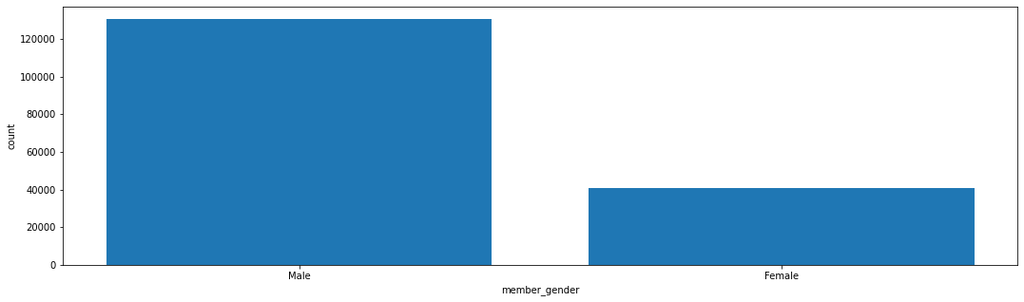

in the figure , there are bar plot to showup and compare between in number of users whether male or female

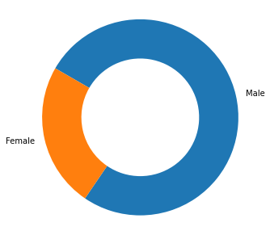

in the figure , there are pie chart to showup and compare between in number of users whether male or female

```
array(['Customer', 'Subscriber'], dtype=object)
```

```
Subscriber    155189
Customer       16116
Name: user_type, dtype: int64
```

## Distribution of user_type

in the figure , there are bar plot / pie_chart to showup and compare between in user_type whether customer or subscribe

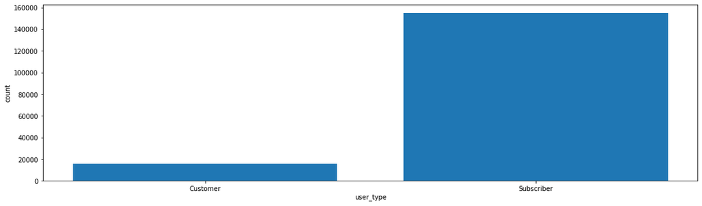

in the figure , there are bar plot to showup and compare between in number of users whether customer or subscriber

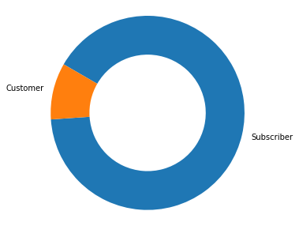

in the figure , there are pie chart to showup and compare between in number of users whether customer or subscriber

```
<class 'pandas.core.frame.DataFrame'>
RangeIndex: 171305 entries, 0 to 171304
Data columns (total 22 columns):
 #   Column                   Non-Null Count   Dtype
---  ------                   --------------   -----
 0   Unnamed: 0               171305 non-null  int64
 1   duration_sec             171305 non-null  int64
 2   start_time               171305 non-null  object
 3   end_time                 171305 non-null  object
 4   start_station_id         171305 non-null  float64
 5   start_station_name       171305 non-null  object
 6   start_station_latitude   171305 non-null  float64
 7   start_station_longitude  171305 non-null  float64
 8   end_station_id           171305 non-null  float64
 9   end_station_name         171305 non-null  object
 10  end_station_latitude     171305 non-null  float64
 11  end_station_longitude    171305 non-null  float64
 12  bike_id                  171305 non-null  int64
 13  user_type                171305 non-null  object
 14  member_birth_year        171305 non-null  float64
 15  member_gender            171305 non-null  object
 16  bike_share_for_all_trip  171305 non-null  object
 17  duration_minu            171305 non-null  float64
 18  duration_hr              171305 non-null  float64
 19  duration_days            171305 non-null  float64
 20  duration_weeks           171305 non-null  float64
 21  duration_months          171305 non-null  float64
dtypes: float64(12), int64(3), object(7)
memory usage: 28.8+ MB
```

```
1988.0    10015
1993.0     9145
1989.0     8805
1990.0     8495
1991.0     8339
          ...
1938.0        3
1944.0        2
1934.0        2
1878.0        1
1927.0        1
Name: member_birth_year, Length: 72, dtype: int64
```

```
array([1984., 1972., 1974., 1959., 1983., 1989., 1992., 1996., 1993.,
       1990., 1988., 1981., 1975., 1978., 1991., 1997., 1986., 2000.,
       1982., 1995., 1980., 1973., 1985., 1971., 1979., 1967., 1998.,
       1994., 1977., 1999., 1987., 1969., 1963., 1976., 1964., 1965.,
       1961., 1968., 1966., 1962., 1954., 1958., 1960., 1970., 1956.,
       1957., 1945., 1900., 1952., 1948., 1951., 1941., 1950., 1949.,
       1953., 1955., 1946., 1947., 1931., 1943., 1942., 1920., 1933.,
       2001., 1878., 1901., 1944., 1934., 1939., 1902., 1938., 1927.])
```